# Lab 04 - La Quinta is Spanish for next to Denny’s, Pt. 2

### Load packages and data

```r
library(tidyverse)
library(dsbox)
```

```r
states <- read_csv("C:/Users/markf/Downloads/DS 241/states.csv")
```

[output not shown]

### Exercise 1

Filter the Denny’s dataframe for Alaska (AK) and save the result as dn_ak. How many Denny’s locations are there in Alaska?

```r
dn_ak <- dennys %>%
  filter(state == "AK")
nrow(dn_ak)
```

```
[1] 3
```

Filter the La Quinta dataframe for Alaska (AK) and save the result as lq_ak. How many La Quinta locations are there in Alaska?

```r
lq_ak <- laquinta %>%
  filter(state == "AK")
nrow(lq_ak)
```

```
[1] 2
```

There are 2 locations in Alaska

Next we’ll calculate the distance between all Denny’s and all La Quinta locations in Alaska.

### Exercise 3

How many pairings are there between all Denny’s and all La Quinta locations in Alaska, i.e. how many distances do we need to calculate between the locations of these establishments in Alaska?

There are 6 pairings, which means we have to calculate 6 distances …

```r
dn_lq_ak <- full_join(dn_ak, lq_ak, by = "state")
dn_lq_ak
```

| address.x | city.x | state | zip.x | longitude.x | latitude.x | address.y | city.y | zip.y | longitude.y | latitude.y | country | establishment |
| --- | --- | --- | --- | --- | --- | --- | --- | --- | --- | --- | --- | --- |
| 2900 Denali | Anchorage | AK | 99503 | -149.8767 | 61.1953 | 3501 Minnesota Dr. | \nAnchorage | 99503 | -149.9119 | 61.18843 | United States | La Quinta |
| 2900 Denali | Anchorage | AK | 99503 | -149.8767 | 61.1953 | 4920 Dale Rd | \nFairbanks | 99709 | -147.8660 | 64.82426 | United States | La Quinta |
| 3850 Debarr Road | Anchorage | AK | 99508 | -149.8090 | 61.2097 | 3501 Minnesota Dr. | \nAnchorage | 99503 | -149.9119 | 61.18843 | United States | La Quinta |
| 3850 Debarr Road | Anchorage | AK | 99508 | -149.8090 | 61.2097 | 4920 Dale Rd | \nFairbanks | 99709 | -147.8660 | 64.82426 | United States | La Quinta |
| 1929 Airport Way | Fairbanks | AK | 99701 | -147.7600 | 64.8366 | 3501 Minnesota Dr. | \nAnchorage | 99503 | -149.9119 | 61.18843 | United States | La Quinta |
| 1929 Airport Way | Fairbanks | AK | 99701 | -147.7600 | 64.8366 | 4920 Dale Rd | \nFairbanks | 99709 | -147.8660 | 64.82426 | United States | La Quinta |

### Exercise 4

How many observations are in the joined dn_lq_ak data frame? What are the names of the variables in this data frame.

There are 6 observations. The names of the variables are adress, city, state, zip code, longitude, latitude, establishment. The variables then repeat for laquinta …

### Exercise 5

What function from the tidyverse do we use the add a new variable to a data frame while keeping the existing variables?

The function we would use is the mutate funciton …

```r
haversine <- function(long1, lat1, long2, lat2, round = 3) {
  # convert to radians
  long1 = long1 * pi / 180
  lat1  = lat1  * pi / 180
  long2 = long2 * pi / 180
  lat2  = lat2  * pi / 180

  R = 6371 # Earth mean radius in km

  a = sin((lat2 - lat1)/2)^2 + cos(lat1) * cos(lat2) * sin((long2 - long1)/2)^2
  d = R * 2 * asin(sqrt(a))

  return( round(d,round) ) # distance in km
}
```

### Exercise 6

Calculate the distances between all pairs of Denny’s and La Quinta locations and save this variable as distance. Make sure to save this variable in THE dn_lq_ak data frame so that you can use it later. …

```r
dn_lq_ak <- dn_lq_ak %>%
  mutate(distance = haversine(longitude.x, latitude.x, longitude.y, latitude.y, round = 1))
```

### Exercise 7

Calculate the minimum distance between a Denny’s and La Quinta for each Denny’s location. To do so we group by Denny’s locations and calculate a new variable that stores the information for the minimum distance. …

```r
dn_lq_ak_mindist <- dn_lq_ak %>%
  group_by(address.x) %>%
  summarise(closest = min(distance))
```

### Exercise 8

Describe the distribution of the distances Denny’s and the nearest La Quinta locations in Alaska. Also include an appripriate visualization and relevant summary statistics. …

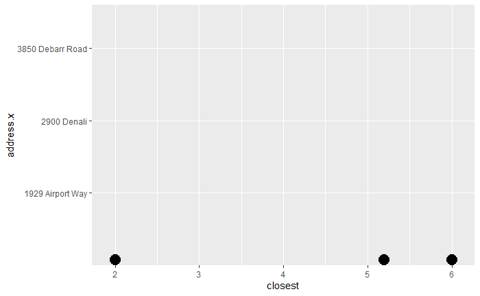

```r
ggplot(data = dn_lq_ak_mindist) +
  geom_dotplot(mapping = aes(x = closest, y = address.x))
```

The distribution of the data is skewed left.

```r
summary(dn_lq_ak_mindist)
```

```
  address.x            closest
 Length:3           Min.   :2.0
 Class :character   1st Qu.:3.6
 Mode  :character   Median :5.2
                    Mean   :4.4
                    3rd Qu.:5.6
                    Max.   :6.0
```

### Exercise 9

Repeat the same analysis for North Carolina:

1. filter Denny’s and La Quinta Data Frames for NC,
2. join these data frames to get a completelist of all possible pairings,
3. calculate the distances between all possible pairings of Denny’s and La Quinta in NC,
4. find the minimum distance between each Denny’s and La Quinta location,
5. visualize and describe the distribution of these shortest distances using appropriate summary statistics.
6. create a function that allows steps i-v to be done quickly to any other state …

complete step i

```r
dn_nc <- dennys %>%
  filter(state == "NC")
nrow(dn_nc)
```

```
[1] 28
```

repreat for laquinta

```r
lq_nc <- laquinta %>%
  filter(state == "NC")
nrow(lq_nc)
```

```
[1] 12
```

Complete step ii

```r
dn_lq_nc <- full_join(dn_nc, lq_nc, by = "state")
dn_lq_nc
```

| address.x | city.x | state | zip.x | longitude.x | latitude.x | address.y | city.y | zip.y | longitude.y | latitude.y | country | establishment |
| --- | --- | --- | --- | --- | --- | --- | --- | --- | --- | --- | --- | --- |
| 1 Regent Park Boulevard | Asheville | NC | 28806 | -82.5820 | 35.5888 | 165 Hwy 105 Extension | \nBoone | 28607 | -81.66881 | 36.21550 | United States | La Quinta |
| 1 Regent Park Boulevard | Asheville | NC | 28806 | -82.5820 | 35.5888 | 3127 Sloan Dr | \nCharlotte | 28208 | -80.92088 | 35.24087 | United States | La Quinta |
| 1 Regent Park Boulevard | Asheville | NC | 28806 | -82.5820 | 35.5888 | 4900 South Tryon St | \nCharlotte | 28217 | -80.89117 | 35.17895 | United States | La Quinta |
| 1 Regent Park Boulevard | Asheville | NC | 28806 | -82.5820 | 35.5888 | 4414 Durham Chapel Hill Blvd | \nDurham | 27707 | -78.97218 | 35.96460 | United States | La Quinta |
| 1 Regent Park Boulevard | Asheville | NC | 28806 | -82.5820 | 35.5888 | 1910 Westpark Dr | \nDurham | 27713 | -78.89145 | 35.90796 | United States | La Quinta |
| 1 Regent Park Boulevard | Asheville | NC | 28806 | -82.5820 | 35.5888 | 1201 Lanada Rd | \nGreensboro | 27407 | -79.89346 | 36.05371 | United States | La Quinta |
| 1 Regent Park Boulevard | Asheville | NC | 28806 | -82.5820 | 35.5888 | 1607 Fairgrove Church Rd | \nConover | 28613 | -81.26184 | 35.70027 | United States | La Quinta |
| 1 Regent Park Boulevard | Asheville | NC | 28806 | -82.5820 | 35.5888 | 191 Crescent Commons | \nCary | 27518 | -78.78415 | 35.73580 | United States | La Quinta |
| 1 Regent Park Boulevard | Asheville | NC | 28806 | -82.5820 | 35.5888 | 2211 Summit Park Ln | \nRaleigh | 27612 | -78.67605 | 35.83362 | United States | La Quinta |
| 1 Regent Park Boulevard | Asheville | NC | 28806 | -82.5820 | 35.5888 | 1001 Aerial Center Pkwy | \nMorrisville | 27560 | -78.81659 | 35.85856 | United States | La Quinta |

[output cut: 326 more lines]

complete step iii

```r
dn_lq_nc <- dn_lq_nc %>%
  mutate(distance = haversine(longitude.x, latitude.x, longitude.y, latitude.y, round = 1))
```

complete step iv

```r
dn_lq_nc_mindist <- dn_lq_nc %>%
  group_by(address.x) %>%
  summarise(closest = min(distance))
```

complete step v

```r
summary(dn_lq_nc_mindist)
```

```
  address.x            closest
 Length:28          Min.   :  1.80
 Class :character   1st Qu.: 22.40
 Mode  :character   Median : 53.45
                    Mean   : 65.44
                    3rd Qu.: 94.00
                    Max.   :187.90
```

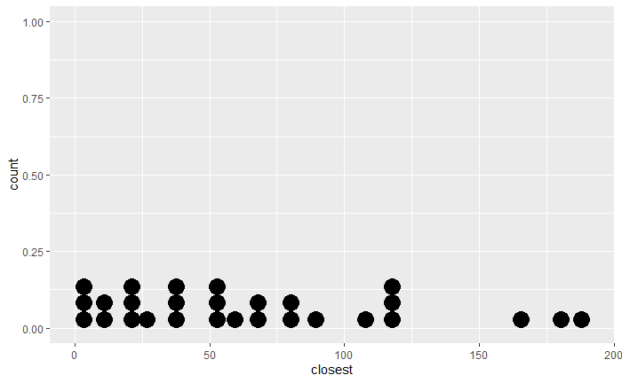

```r
ggplot(data = dn_lq_nc_mindist) +
  geom_dotplot(mapping = aes(x = closest))
```

complete step vi

```r
map_mindist <- function(which_state) {
  #step i
  x = which_state

  dn_x <- dennys %>%
  filter(state == x)

  lq_x <- laquinta %>%
  filter(state == x)

  dn_lq_x <- full_join(dn_x, lq_x, by = "state") %>%
  mutate(distance = haversine(longitude.x, latitude.x, longitude.y, latitude.y, round = 1))

  dn_lq_x_mindist <- dn_lq_x %>%
  group_by(address.x) %>%
  summarise(closest = min(distance))

#The below code will help you quickly print visualizations or summary statistics

# summary(dn_lq_x_mindist)
# ggplot(data = dn_lq_x_mindist) +
#   geom_dotplot(mapping = aes(x = closest))

}
```

This code chunk may be disregarded. It was only used for development of the above funtion.

```r
# map_mindist("TX")
```

### Exercise 10

Repeat the same analysis for Texas. …

```r
dn_lq_tx_mindist <- map_mindist("TX")
summary(dn_lq_tx_mindist)
```

```
  address.x            closest
 Length:200         Min.   : 0.000
 Class :character   1st Qu.: 0.700
 Mode  :character   Median : 3.350
                    Mean   : 5.792
                    3rd Qu.: 6.625
                    Max.   :60.600
```

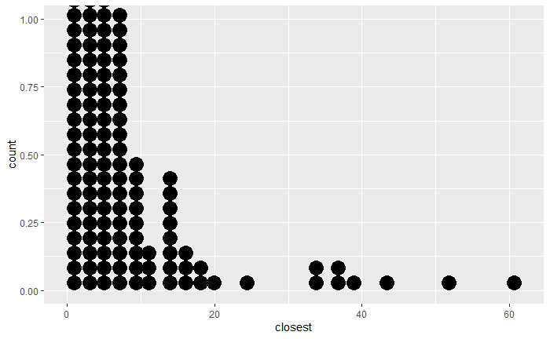

```r
   ggplot(data = dn_lq_tx_mindist) +
    geom_dotplot(mapping = aes(x = closest))
```

### Exercise 11

Repeat the same analysis for a state of your choosing, different than the ones we covered so far. …

```r
dn_lq_ny_mindist <- map_mindist("NY")
summary(dn_lq_ny_mindist)
```

```
  address.x            closest
 Length:56          Min.   : 1.300
 Class :character   1st Qu.: 7.425
 Mode  :character   Median :24.200
                    Mean   :33.577
                    3rd Qu.:53.300
                    Max.   :99.000
```

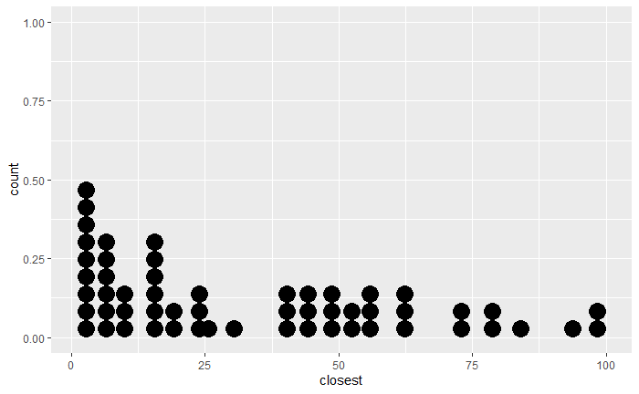

```r
   ggplot(data = dn_lq_ny_mindist) +
    geom_dotplot(mapping = aes(x = closest))
```

### Exercise 12

Among the states you examined, where is Mitch Hedberg’s joke most likely to hold true? Explain your reasoning.

… Among the states I examined, North Carolina, Texas, and New York, Mitch Hedberg’s joke is most likely to hold true for Texas. The reason for this is that the mean minimum distance between a Denny’s and the Nearest LaQuinta is the lowest. In Texas, the mean minimum distance is 5.792. For North Carolina and New York, the mean minimum distances are 65.44 and 33.577 respectively